# Assignment - Dimension Reduction

## Loading the Data

```r
data_assignment_2 <- read.csv(
  file = "C:/Users/Suma Marri/Documents/GitHub/USCars/USA_cars_datasets.csv",
  colClasses = "character"
  )
data_assignment_2
```

| X | price | brand | model | year | title_status | mileage | color | vin | lot | state | country | condition |
| --- | --- | --- | --- | --- | --- | --- | --- | --- | --- | --- | --- | --- |
| 0 | 6300 | toyota | cruiser | 2008 | clean vehicle | 274117.0 | black | jtezu11f88k007763 | 159348797 | new jersey | usa | 10 days left |
| 1 | 2899 | ford | se | 2011 | clean vehicle | 190552.0 | silver | 2fmdk3gc4bbb02217 | 166951262 | tennessee | usa | 6 days left |
| 2 | 5350 | dodge | mpv | 2018 | clean vehicle | 39590.0 | silver | 3c4pdcgg5jt346413 | 167655728 | georgia | usa | 2 days left |
| 3 | 25000 | ford | door | 2014 | clean vehicle | 64146.0 | blue | 1ftfw1et4efc23745 | 167753855 | virginia | usa | 22 hours left |
| 4 | 27700 | chevrolet | 1500 | 2018 | clean vehicle | 6654.0 | red | 3gcpcrec2jg473991 | 167763266 | florida | usa | 22 hours left |
| 5 | 5700 | dodge | mpv | 2018 | clean vehicle | 45561.0 | white | 2c4rdgeg9jr237989 | 167655771 | texas | usa | 2 days left |
| 6 | 7300 | chevrolet | pk | 2010 | clean vehicle | 149050.0 | black | 1gcsksea1az121133 | 167753872 | georgia | usa | 22 hours left |
| 7 | 13350 | gmc | door | 2017 | clean vehicle | 23525.0 | gray | 1gks2gkc3hr326762 | 167692494 | california | usa | 20 hours left |
| 8 | 14600 | chevrolet | malibu | 2018 | clean vehicle | 9371.0 | silver | 1g1zd5st5jf191860 | 167763267 | florida | usa | 22 hours left |
| 9 | 5250 | ford | mpv | 2017 | clean vehicle | 63418.0 | black | 2fmpk3j92hbc12542 | 167656121 | texas | usa | 2 days left |

[output cut: 990 more lines]

This US Cars Dataset data is from the Kaggle Repository and was scraped from AUCTION EXPORT.com. The dataset includes information about 28 brands of clean and used vehicles for sale in US.

For this assignment, the focus will be on the target variable as brand and the predictor variables will be mileage, year, and the price of the vehicle. The analysis will be based on predicting car brands based on a vehicle’s year, price, and mileage. These make the most sense as the assumption is made that these are the attributes that anyone buying a car looks at when putting a price stamp according to the brand. For example, German vehicles are usually in the higher price bracket compared to American vehicles.

Since dimension reduction uses continuous variables, lets organize the dataframe which makes more sense for the purpose of our problem. The organization will be implemented using the predictor variables listed above and dummy coding for categorical predictor variables. We can then perform analysis based on a new dataframe.

## Organized Dataframe and Dummy Coding

```r
price <- as.double(data_assignment_2$price)
mileage <- as.double(data_assignment_2$mileage)
brand <- as.character(data_assignment_2$brand)
year <- as.character(data_assignment_2$year)

d <- data.frame(brand, price, mileage, year)
d
```

| brand | price | mileage | year |
| --- | --- | --- | --- |
| toyota | 6300 | 274117 | 2008 |
| ford | 2899 | 190552 | 2011 |
| dodge | 5350 | 39590 | 2018 |
| ford | 25000 | 64146 | 2014 |
| chevrolet | 27700 | 6654 | 2018 |
| dodge | 5700 | 45561 | 2018 |
| chevrolet | 7300 | 149050 | 2010 |
| gmc | 13350 | 23525 | 2017 |
| chevrolet | 14600 | 9371 | 2018 |
| ford | 5250 | 63418 | 2017 |

[output cut: 990 more lines]

```r
library(fastDummies)
d_dummy <- dummy_cols(d, select_columns = 'year',
                      remove_selected_columns = TRUE)
d_dummy
```

| brand | price | mileage | year_1973 | year_1984 | year_1993 | year_1994 | year_1995 | year_1996 | year_1997 | year_1998 | year_1999 | year_2000 | year_2001 | year_2002 | year_2003 | year_2004 | year_2005 | year_2006 | year_2007 | year_2008 | year_2009 | year_2010 | year_2011 | year_2012 | year_2013 | year_2014 | year_2015 | year_2016 | year_2017 | … |
| --- | --- | --- | --- | --- | --- | --- | --- | --- | --- | --- | --- | --- | --- | --- | --- | --- | --- | --- | --- | --- | --- | --- | --- | --- | --- | --- | --- | --- | --- | --- |
| toyota | 6300 | 274117 | 0 | 0 | 0 | 0 | 0 | 0 | 0 | 0 | 0 | 0 | 0 | 0 | 0 | 0 | 0 | 0 | 0 | 1 | 0 | 0 | 0 | 0 | 0 | 0 | 0 | 0 | 0 | … |
| ford | 2899 | 190552 | 0 | 0 | 0 | 0 | 0 | 0 | 0 | 0 | 0 | 0 | 0 | 0 | 0 | 0 | 0 | 0 | 0 | 0 | 0 | 0 | 1 | 0 | 0 | 0 | 0 | 0 | 0 | … |
| dodge | 5350 | 39590 | 0 | 0 | 0 | 0 | 0 | 0 | 0 | 0 | 0 | 0 | 0 | 0 | 0 | 0 | 0 | 0 | 0 | 0 | 0 | 0 | 0 | 0 | 0 | 0 | 0 | 0 | 0 | … |
| ford | 25000 | 64146 | 0 | 0 | 0 | 0 | 0 | 0 | 0 | 0 | 0 | 0 | 0 | 0 | 0 | 0 | 0 | 0 | 0 | 0 | 0 | 0 | 0 | 0 | 0 | 1 | 0 | 0 | 0 | … |
| chevrolet | 27700 | 6654 | 0 | 0 | 0 | 0 | 0 | 0 | 0 | 0 | 0 | 0 | 0 | 0 | 0 | 0 | 0 | 0 | 0 | 0 | 0 | 0 | 0 | 0 | 0 | 0 | 0 | 0 | 0 | … |
| dodge | 5700 | 45561 | 0 | 0 | 0 | 0 | 0 | 0 | 0 | 0 | 0 | 0 | 0 | 0 | 0 | 0 | 0 | 0 | 0 | 0 | 0 | 0 | 0 | 0 | 0 | 0 | 0 | 0 | 0 | … |
| chevrolet | 7300 | 149050 | 0 | 0 | 0 | 0 | 0 | 0 | 0 | 0 | 0 | 0 | 0 | 0 | 0 | 0 | 0 | 0 | 0 | 0 | 0 | 1 | 0 | 0 | 0 | 0 | 0 | 0 | 0 | … |
| gmc | 13350 | 23525 | 0 | 0 | 0 | 0 | 0 | 0 | 0 | 0 | 0 | 0 | 0 | 0 | 0 | 0 | 0 | 0 | 0 | 0 | 0 | 0 | 0 | 0 | 0 | 0 | 0 | 0 | 1 | … |
| chevrolet | 14600 | 9371 | 0 | 0 | 0 | 0 | 0 | 0 | 0 | 0 | 0 | 0 | 0 | 0 | 0 | 0 | 0 | 0 | 0 | 0 | 0 | 0 | 0 | 0 | 0 | 0 | 0 | 0 | 0 | … |
| ford | 5250 | 63418 | 0 | 0 | 0 | 0 | 0 | 0 | 0 | 0 | 0 | 0 | 0 | 0 | 0 | 0 | 0 | 0 | 0 | 0 | 0 | 0 | 0 | 0 | 0 | 0 | 0 | 0 | 1 | … |

[output cut: 990 more lines]

```r
dim(d_dummy)
```

```
[1] 2499   33
```

The result after dummy coding produces a large number of predictor columns.

#### Levels of the target variable ‘brand’

```r
table(d_dummy$brand)
```

```
          acura            audi             bmw           buick        cadillac       chevrolet        chrysler
              3               4              17              13              10             297              18
          dodge            ford             gmc harley-davidson       heartland           honda         hyundai
            432            1235              42               1               5              12              15
       infiniti          jaguar            jeep             kia            land           lexus         lincoln
             12               1              30              13               4               2               2
       maserati           mazda   mercedes-benz          nissan       peterbilt             ram          toyota
              1               2              10             312               4               1               1
```

## PCA

Since we are dealing with a high number of predictors and we have dummy variables as well, we can perform Principal Component Analysis to reduce the number of predictor variables. This is the first technique used in this problem for dimension reduction. Usually, dimension reduction techniques are not used on non-continuous variables, however, for the purpose of this problem, we have already encoded the non-continuous variables with dummy variables, so we can perform dimension reduction and see the results.

#### Creating a color vector corresponding to the target variable

```r
brand_color <- viridis::viridis(28)
names(brand_color) <- sort(unique(d_dummy$brand))
brand_color <- brand_color[d_dummy$brand]
```

#### Principal Component Analysis (RANK 2 PCA) - Visualizations (Biplot and Screeplot)

```r
D <- d_dummy[,colnames(d_dummy)!="brand"]
prcomp_D <- prcomp(
  x=D,
  center=TRUE,
  scale.=TRUE,
  rank. = 2
)

round(summary(prcomp_D)$importance,2)
```

```
                        PC1  PC2
Standard deviation     1.47 1.14 1.09 1.05 1.04 1.02 1.02 1.01 1.01 1.01 1.00 1.00 1.00 1.00 1.00 1.00 1.00 1.00 1.00 1.00
Proportion of Variance 0.07 0.04 0.04 0.03 0.03 0.03 0.03 0.03 0.03 0.03 0.03 0.03 0.03 0.03 0.03 0.03 0.03 0.03 0.03 0.03
Cumulative Proportion  0.07 0.11 0.15 0.18 0.21 0.25 0.28 0.31 0.34 0.37 0.41 0.44 0.47 0.50 0.53 0.56 0.59 0.63 0.66 0.69

Standard deviation     1.00 1.00 1.00 1.00 1.00 1.00 1.00 1.00 1.00 0.79 0.58 0
Proportion of Variance 0.03 0.03 0.03 0.03 0.03 0.03 0.03 0.03 0.03 0.02 0.01 0
Cumulative Proportion  0.72 0.75 0.78 0.81 0.84 0.88 0.91 0.94 0.97 0.99 1.00 1
```

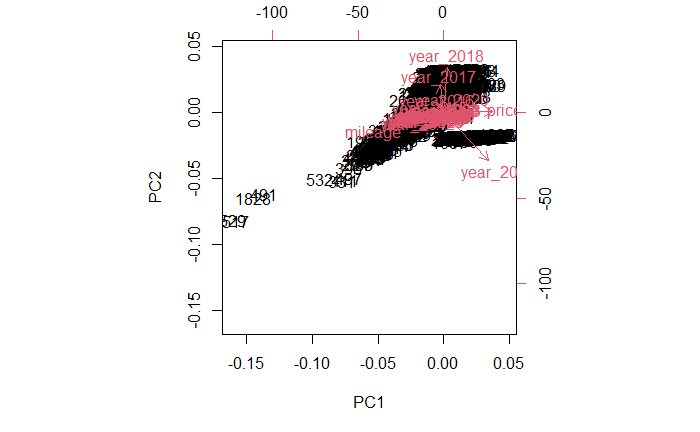

```r
biplot(prcomp_D)
```

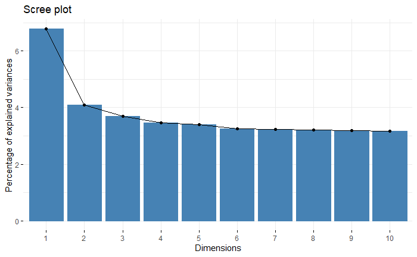

```r
factoextra::fviz_eig(prcomp_D)
```

#### Lets look at how well theese 2 predictors perform:

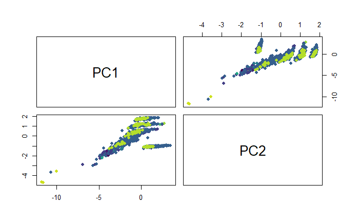

```r
pairs(prcomp_D$x[,1:2], col=brand_color, pch=19)
```

#### Looking at the scatterplots above, we can be confident in performing rank two PCA analysis since the scatter plots seem to be a reflection of each other.

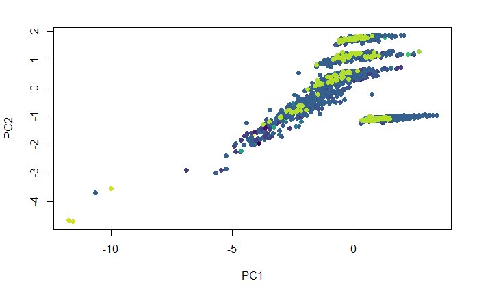

```r
plot(prcomp_D$x[,1:2],col=brand_color,pch=19)
```

In the plot above, we can see separation between the colors. Although, most of the data points in the scatter plot are close together but a slight separation can still be seen. Only a few predictors could be distinguished looking at this plot, since most of the data points are clumped together.

#### Using rotation matrix to interpret the Principal Components

##### PC1

```r
v <- sort(prcomp_D$rotation[,"PC1"])
v <- v[abs(v) > 0.15]
M <- matrix(v)
rownames(M) <- names(v)
M
```

```
                [,1]
mileage   -0.5600880
year_2012 -0.2012375
year_2013 -0.1888575
year_2019  0.4434452
price      0.4854187
```

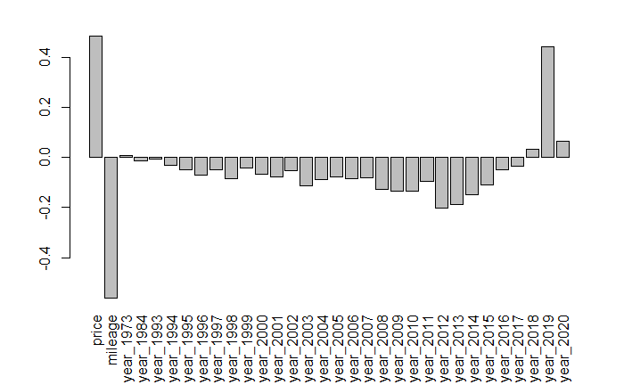

```r
par(las=3)
barplot(prcomp_D$rotation[,"PC1"])
```

##### PC2

```r
v <- sort(prcomp_D$rotation[,"PC2"])
v <- v[abs(v) > 0.15]
M <- matrix(v)
rownames(M) <- names(v)
M
```

```
                [,1]
year_2019 -0.6122358
mileage   -0.2035003
year_2017  0.3587926
year_2018  0.5746513
```

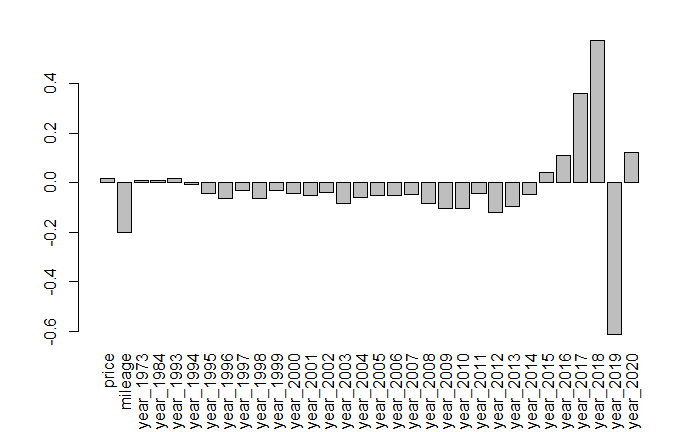

```r
par(las=3)
barplot(prcomp_D$rotation[,"PC2"])
```

From the rotation matrix interpretation, we can interpret for PC1 that price, mileage, and year_2019 are good predictors of brand. Whereas for PC2, year_2017, year_2018, and year_2019 are good predictors of brand. The predictors are interpreted on being strong predictors based on the correlation values on the higher ends (negative or positive). If we perform feature engineering, maybe price and year_2019 can form a better predictor, or price and mileage can be formulated in to a solid predictor.

#### Scatterplot for the two components

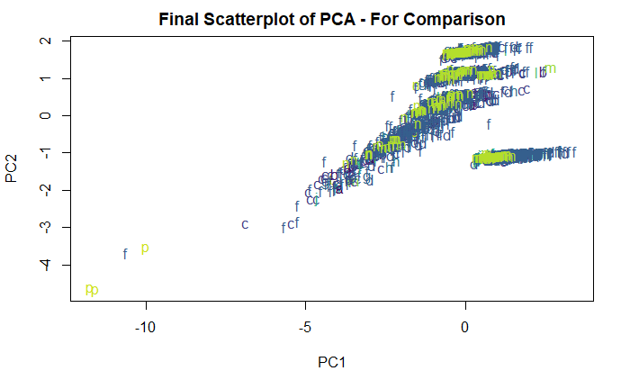

```r
plot(prcomp_D$x[,1:2],
     col = brand_color,
     pch = as.character(brand),
     main = "Final Scatterplot of PCA - For Comparison")
```

We can see in this Final Scatter Plot for PCA above that most of the data is clumped together where only p can be distinguished from all the points. Even though the data points are all clumped together, grouping and categories can be seen for the data points.